# Data Exploration (Erweiterte Version)

Analyse und Aufbereitung des **UCI Hydraulic Systems** Dataset mit verbesserter Reihenfolge:

1. Zielvariablen verstehen
2. Rohdaten Quality Check (BEVOR Aggregation!)
3. Feature Engineering / Aggregation
4. Feature Selection (redundante Features entfernen)
5. Korrelationsanalyse auf bereinigtem Dataset

## 1. Import und Zielvariablen

```python
import pandas as pd
import numpy as np
import matplotlib.pyplot as plt
import seaborn as sns
from pathlib import Path

plt.rcParams['figure.figsize'] = (12, 6)
sns.set_style("whitegrid")
sns.set_palette("husl")

DATA_DIR = Path('../data')
DOCS_DIR = Path('../docs')
OUT_DIR = Path('../out')

print("✓ Bibliotheken und Pfade definiert")
```

```
✓ Bibliotheken und Pfade definiert
```

```python
# Zielvariablen laden
target_names = ['cooler_condition', 'valve_condition', 'pump_leakage', 'accumulator_pressure', 'stable_flag']
targets = pd.read_csv(DOCS_DIR / 'profile.txt', sep='\t', header=None, names=target_names)

print(f"✓ Zielvariablen geladen: {targets.shape}")
print(f"Spalten: {list(targets.columns)}")
display(targets.head())
```

```
✓ Zielvariablen geladen: (2205, 5)
Spalten: ['cooler_condition', 'valve_condition', 'pump_leakage', 'accumulator_pressure', 'stable_flag']
```

|  | cooler_condition | valve_condition | pump_leakage | accumulator_pressure | stable_flag |
| --- | --- | --- | --- | --- | --- |
| 0 | 3 | 100 | 0 | 130 | 1 |
| 1 | 3 | 100 | 0 | 130 | 1 |
| 2 | 3 | 100 | 0 | 130 | 1 |
| 3 | 3 | 100 | 0 | 130 | 1 |
| 4 | 3 | 100 | 0 | 130 | 1 |

## 2. Quality Check: Rohdaten BEVOR Aggregation

**Wichtig:** Wir prüfen die **Rohdaten** auf Missings und Plausibilität, BEVOR wir sie aggregieren!

Nach der Aggregation sind fehlende Werte praktisch unmöglich: Wenn eine Zeitreihe Missings hat, werden diese bei `mean()`, `std()`, etc. einfach ignoriert → keine Missings im Output

```python
# Rohdaten Quality Check: ALLE 2205 Zyklen analysieren
print("=" * 70)
print("ROHDATEN QUALITY CHECK (VOLLSTÄNDIG)")
print("=" * 70)

sensor_files = [
    'PS1', 'PS2', 'PS3', 'PS4', 'PS5', 'PS6',
    'EPS1', 'FS1', 'FS2', 'TS1', 'TS2', 'TS3', 'TS4',
    'VS1', 'CE', 'CP', 'SE'
]

# Für jeden Sensor: Lade ALLE Zeitreihen und berechne Statistiken
raw_data_full = {}
for sensor in sensor_files:
    file_path = DATA_DIR / f'{sensor}.txt'
    if file_path.exists():
        # Lade ALLE Zyklen (2205 Zeilen)
        all_cycles = np.loadtxt(file_path, dtype=float)
        raw_data_full[sensor] = all_cycles

print(f"\n✓ {len(raw_data_full)} Sensoren geladen")
print(f"✓ Jeweils {raw_data_full[sensor_files[0]].shape[0]} Zyklen (Zeilen)")
print(f"✓ Jeweils {raw_data_full[sensor_files[0]].shape[1]} Zeitpunkte (Spalten)\n")

# Aggregierte Statistiken über ALLE Zyklen
print("=" * 70)
print("AGGREGIERTE SENSOR-STATISTIKEN (über alle 2205 Zyklen)")
print("=" * 70)
print(f"{'Sensor':<6} | {'Timepoints':<10} | {'Min':<10} | {'Max':<10} | {'Mean':<10} | {'Std':<10} | {'NaN':<6}")
print("-" * 70)

for sensor, data in raw_data_full.items():
    n_cycles = data.shape[0]
    n_timepoints = data.shape[1]

    # Statistiken über ALLE Werte (alle Zyklen × alle Zeitpunkte)
    all_values = data.flatten()
    min_val = np.nanmin(all_values)
    max_val = np.nanmax(all_values)
    mean_val = np.nanmean(all_values)
    std_val = np.nanstd(all_values)
    n_nan = np.isnan(all_values).sum()

    print(f"{sensor:<6} | {n_timepoints:<10} | {min_val:<10.2f} | {max_val:<10.2f} | "
          f"{mean_val:<10.2f} | {std_val:<10.2f} | {n_nan:<6}")

raw_data_sample = {sensor: data[0] for sensor, data in raw_data_full.items()}
```

```
======================================================================
ROHDATEN QUALITY CHECK (VOLLSTÄNDIG)
======================================================================

✓ 17 Sensoren geladen
✓ Jeweils 2205 Zyklen (Zeilen)
✓ Jeweils 6000 Zeitpunkte (Spalten)

======================================================================
AGGREGIERTE SENSOR-STATISTIKEN (über alle 2205 Zyklen)
======================================================================
Sensor | Timepoints | Min        | Max        | Mean       | Std        | NaN
----------------------------------------------------------------------
PS1    | 6000       | 133.13     | 191.92     | 160.49     | 16.13      | 0
PS2    | 6000       | 0.00       | 167.77     | 109.38     | 48.10      | 0
PS3    | 6000       | 0.00       | 18.83      | 1.75       | 0.93       | 0
PS4    | 6000       | 0.00       | 10.27      | 2.60       | 4.30       | 0
PS5    | 6000       | 8.32       | 10.04      | 9.16       | 0.58       | 0
PS6    | 6000       | 8.27       | 9.91       | 9.08       | 0.55       | 0
EPS1   | 6000       | 2097.80    | 2995.20    | 2495.51    | 218.22     | 0
FS1    | 600        | 0.00       | 20.48      | 6.20       | 3.21       | 0
FS2    | 600        | 8.76       | 10.45      | 9.65       | 0.45       | 0
TS1    | 60         | 34.98      | 58.21      | 45.42      | 7.99       | 0
TS2    | 60         | 40.71      | 62.18      | 50.37      | 7.40       | 0
TS3    | 60         | 38.15      | 59.54      | 47.66      | 7.45       | 0
TS4    | 60         | 30.36      | 53.15      | 40.74      | 8.11       | 0
VS1    | 60         | 0.48       | 2.55       | 0.61       | 0.08       | 0
CE     | 60         | 17.04      | 48.78      | 31.30      | 11.58      | 0
CP     | 60         | 1.02       | 2.91       | 1.81       | 0.28       | 0
SE     | 60         | 0.00       | 100.60     | 55.29      | 25.64      | 0
```

```python
# Anomalie-Erkennung: Zyklen mit starken Abweichungen
print("\n" + "=" * 70)
print("ANOMALIE-ERKENNUNG: ZYKLEN MIT EXTREMEN WERTEN")
print("=" * 70)

anomalies = []
for sensor, data in raw_data_full.items():
    # Berechne Mean pro Zyklus (über alle Zeitpunkte)
    cycle_means = np.nanmean(data, axis=1)

    # Gesamt-Mittelwert und Std über alle Zyklen
    overall_mean = np.nanmean(cycle_means)
    overall_std = np.nanstd(cycle_means)

    # Finde Zyklen mit Abweichung > 3 Standardabweichungen
    z_scores = np.abs((cycle_means - overall_mean) / overall_std)
    outlier_cycles = np.where(z_scores > 3)[0]

    if len(outlier_cycles) > 0:
        # Top 3 extremste Zyklen
        top_outliers = outlier_cycles[np.argsort(z_scores[outlier_cycles])[-3:]][::-1]
        for cycle_idx in top_outliers:
            anomalies.append({
                'Sensor': sensor,
                'Zyklus': cycle_idx + 1,  # 1-indexed
                'Mean': cycle_means[cycle_idx],
                'Z-Score': z_scores[cycle_idx],
                'Abweichung': f"{((cycle_means[cycle_idx] - overall_mean) / overall_mean * 100):.1f}%"
            })

if len(anomalies) > 0:
    anomalies_df = pd.DataFrame(anomalies).sort_values('Z-Score', ascending=False)
    print(f"\n⚠ {len(anomalies)} Anomalien gefunden (Z-Score > 3):\n")
    display(anomalies_df.head(15))
else:
    print("\n✓ KEINE EXTREMEN AUSREISSER GEFUNDEN (Z-Score > 3)")

# Missing Values Analyse (über alle Zyklen)
print("\n" + "=" * 70)
print("MISSING VALUES IN ROHDATEN (über alle 2205 Zyklen)")
print("=" * 70)

missing_summary = []
for sensor, data in raw_data_full.items():
    all_values = data.flatten()
    n_missing = np.isnan(all_values).sum()
    pct_missing = (n_missing / len(all_values)) * 100
    missing_summary.append({
        'Sensor': sensor,
        'Total_Values': len(all_values),
        'Missing': n_missing,
        'Pct_Missing': pct_missing
    })

missing_df = pd.DataFrame(missing_summary)
display(missing_df)

total_values = missing_df['Total_Values'].sum()
total_missing = missing_df['Missing'].sum()
print(f"\nGesamt: {total_missing} fehlende Werte von {total_values:,} ({(total_missing/total_values)*100:.4f}%)")

if total_missing == 0:
    print("✓ KEINE FEHLENDEN WERTE IN ROHDATEN GEFUNDEN")
else:
    print(f"⚠ VORSICHT: {total_missing:,} fehlende Werte in Rohdaten!")
```

```
======================================================================
ANOMALIE-ERKENNUNG: ZYKLEN MIT EXTREMEN WERTEN
======================================================================

⚠ 24 Anomalien gefunden (Z-Score > 3):


⚠ 24 Anomalien gefunden (Z-Score > 3):
```

|  | Sensor | Zyklus | Mean | Z-Score | Abweichung |
| --- | --- | --- | --- | --- | --- |
| 3 | PS2 | 464 | 131.589089 | 4.454796 | 20.3% |
| 4 | PS2 | 592 | 131.524458 | 4.441832 | 20.2% |
| 0 | PS1 | 464 | 180.922708 | 4.349901 | 12.7% |
| 5 | PS2 | 371 | 131.052366 | 4.347138 | 19.8% |
| 1 | PS1 | 592 | 180.867048 | 4.338054 | 12.7% |
| 2 | PS1 | 484 | 180.704613 | 4.303481 | 12.6% |
| 21 | SE | 484 | 18.276617 | 4.131573 | -66.9% |
| 22 | SE | 617 | 18.528983 | 4.103402 | -66.5% |
| 23 | SE | 389 | 19.010267 | 4.049676 | -65.6% |
| 12 | FS1 | 484 | 2.018572 | 4.047822 | -67.4% |
| 13 | FS1 | 617 | 2.029777 | 4.036971 | -67.3% |
| 14 | FS1 | 634 | 2.058517 | 4.009140 | -66.8% |
| 15 | VS1 | 559 | 0.839067 | 3.747155 | 36.8% |
| 18 | CP | 1467 | 2.840100 | 3.708495 | 57.1% |
| 6 | PS3 | 500 | 0.840252 | 3.625152 | -52.1% |

```
======================================================================
MISSING VALUES IN ROHDATEN (über alle 2205 Zyklen)
======================================================================
```

|  | Sensor | Total_Values | Missing | Pct_Missing |
| --- | --- | --- | --- | --- |
| 0 | PS1 | 13230000 | 0 | 0.0 |
| 1 | PS2 | 13230000 | 0 | 0.0 |
| 2 | PS3 | 13230000 | 0 | 0.0 |
| 3 | PS4 | 13230000 | 0 | 0.0 |
| 4 | PS5 | 13230000 | 0 | 0.0 |
| 5 | PS6 | 13230000 | 0 | 0.0 |
| 6 | EPS1 | 13230000 | 0 | 0.0 |
| 7 | FS1 | 1323000 | 0 | 0.0 |
| 8 | FS2 | 1323000 | 0 | 0.0 |
| 9 | TS1 | 132300 | 0 | 0.0 |
| 10 | TS2 | 132300 | 0 | 0.0 |
| 11 | TS3 | 132300 | 0 | 0.0 |
| 12 | TS4 | 132300 | 0 | 0.0 |
| 13 | VS1 | 132300 | 0 | 0.0 |
| 14 | CE | 132300 | 0 | 0.0 |
| 15 | CP | 132300 | 0 | 0.0 |
| 16 | SE | 132300 | 0 | 0.0 |

```
Gesamt: 0 fehlende Werte von 96,314,400 (0.0000%)
✓ KEINE FEHLENDEN WERTE IN ROHDATEN GEFUNDEN
```

```
======================================================================
ZEITREIHEN-VISUALISIERUNG
======================================================================
```

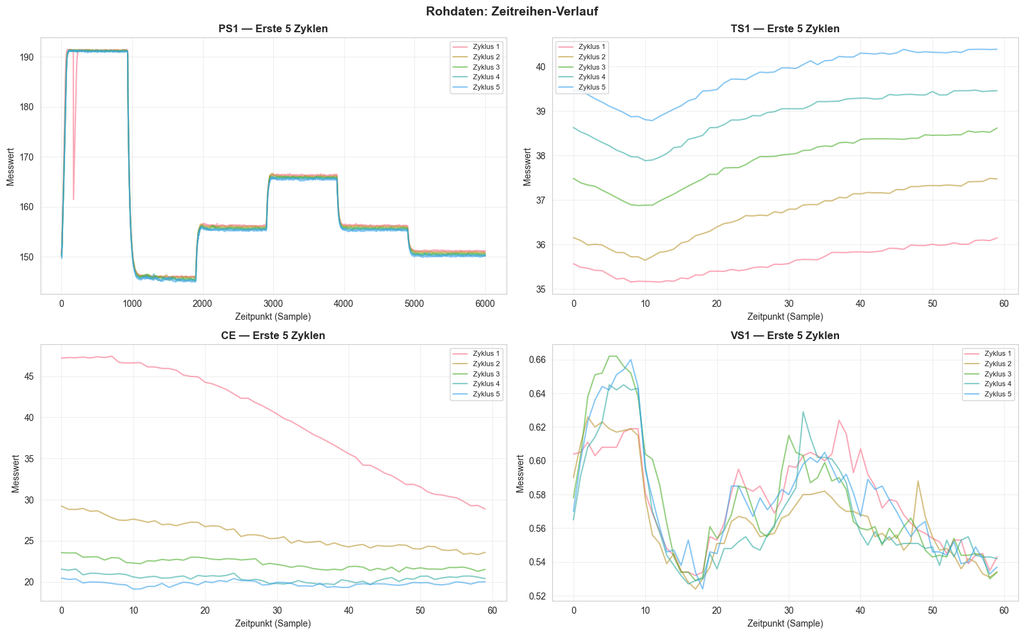

```
✓ Visualisierung für 4 Sensoren erstellt
```

```python
# Visualisierung: Zeitreihen-Plots für ausgewählte Sensoren
print("\n" + "=" * 70)
print("ZEITREIHEN-VISUALISIERUNG")
print("=" * 70)

# Wähle 4 wichtige Sensoren für Visualisierung
selected_sensors = ['PS1', 'TS1', 'CE', 'VS1']
n_cycles_to_plot = 5  # Zeige erste 5 Zyklen

fig, axes = plt.subplots(2, 2, figsize=(16, 10))
axes = axes.flatten()

for idx, sensor in enumerate(selected_sensors):
    if sensor in raw_data_full:
        data = raw_data_full[sensor]

        # Plot erste 5 Zyklen
        for cycle_idx in range(min(n_cycles_to_plot, data.shape[0])):
            axes[idx].plot(data[cycle_idx], alpha=0.6, label=f'Zyklus {cycle_idx+1}')

        axes[idx].set_title(f'{sensor} — Erste {n_cycles_to_plot} Zyklen',
                           fontsize=12, fontweight='bold')
        axes[idx].set_xlabel('Zeitpunkt (Sample)')
        axes[idx].set_ylabel('Messwert')
        axes[idx].legend(loc='best', fontsize=8)
        axes[idx].grid(alpha=0.3)

plt.suptitle('Rohdaten: Zeitreihen-Verlauf', fontsize=14, fontweight='bold')
plt.tight_layout()
plt.show()

print("✓ Visualisierung für 4 Sensoren erstellt")
```

```python
# Plausibilitätsprüfung: Wertebereich Sanity Check
print("\n" + "=" * 70)
print("PLAUSIBILITÄTSPRÜFUNG: SENSORWERTE")
print("=" * 70)

# HINWEIS: Diese Ranges basieren auf UCI Documentation + erste Stichprobe
# CE und SE sind NICHT normalisiert (0-1), sondern absolute Messwerte!
expected_ranges = {
    'PS': (0, 350),        # Drucksensoren: 0-350 bar
    'EPS1': (0, 10000),    # Elektrische Leistung: 0-10 kW
    'FS': (0, 100),        # Volumenstrom: 0-100 l/min
    'TS': (0, 100),        # Temperatur: 0-100°C
    'VS1': (0, 10),        # Vibration: 0-10 mm/s
    'CE': (0, 100),        # Kühleffizienz: INDEX (0-100, nicht 0-1!)
    'CP': (0, 10000),      # Kühlleistung: 0-10 kW
    'SE': (0, 100)         # Effizienzfaktor: Ratio × 100 (0-100, nicht 0-1!)
}

plausibility_check = []
for sensor, data in raw_data_sample.items():
    min_val = np.nanmin(data)
    max_val = np.nanmax(data)
    mean_val = np.nanmean(data)

    # Finde passende Range
    expected_min, expected_max = None, None

    if sensor in expected_ranges:
        expected_min, expected_max = expected_ranges[sensor]
    else:
        for key, (e_min, e_max) in expected_ranges.items():
            if sensor.startswith(key):
                expected_min, expected_max = e_min, e_max
                break

    if expected_min is None:
        expected_min, expected_max = 0, 1000

    # Prüfe: Sind Min/Max im Bereich?
    in_range = (min_val >= expected_min and max_val <= expected_max)
    status = "✓" if in_range else "⚠"

    plausibility_check.append({
        'Sensor': sensor,
        'Status': status,
        'Min': min_val,
        'Max': max_val,
        'Mean': mean_val,
        'Expected_Range': f'[{expected_min}, {expected_max}]'
    })

plaus_df = pd.DataFrame(plausibility_check)
display(plaus_df)

issues = plaus_df[plaus_df['Status'] == '⚠']
if len(issues) == 0:
    print("\n✓ ALLE SENSOREN IN ERWARTETEN WERTEBEREICH")
else:
    print(f"\n⚠ {len(issues)} Sensoren möglicherweise außerhalb (aber evtl. OK):")
    for idx, row in issues.iterrows():
        print(f"   {row['Sensor']:6s}: Min={row['Min']:.2f}, Max={row['Max']:.2f} | Erwartet: {row['Expected_Range']}")
        if row['Sensor'] in ['CE', 'SE']:
            print(f"            → (CE/SE sind INDEX-Werte, nicht normalisiert)")
```

```
======================================================================
PLAUSIBILITÄTSPRÜFUNG: SENSORWERTE
======================================================================
```

|  | Sensor | Status | Min | Max | Mean | Expected_Range |
| --- | --- | --- | --- | --- | --- | --- |
| 0 | PS1 | ✓ | 145.830 | 191.510 | 160.673492 | [0, 350] |
| 1 | PS2 | ✓ | 0.000 | 156.990 | 109.466914 | [0, 350] |
| 2 | PS3 | ✓ | 0.000 | 10.039 | 1.991475 | [0, 350] |
| 3 | PS4 | ✓ | 0.000 | 0.000 | 0.000000 | [0, 350] |
| 4 | PS5 | ✓ | 9.681 | 10.016 | 9.842169 | [0, 350] |
| 5 | PS6 | ✓ | 9.568 | 9.887 | 9.728098 | [0, 350] |
| 6 | EPS1 | ✓ | 2339.800 | 2951.600 | 2538.929167 | [0, 10000] |
| 7 | FS1 | ✓ | 0.000 | 18.710 | 6.709815 | [0, 100] |
| 8 | FS2 | ✓ | 10.148 | 10.446 | 10.304592 | [0, 100] |
| 9 | TS1 | ✓ | 35.156 | 36.152 | 35.621983 | [0, 100] |
| 10 | TS2 | ✓ | 40.773 | 41.250 | 40.978767 | [0, 100] |
| 11 | TS3 | ✓ | 38.316 | 38.613 | 38.471017 | [0, 100] |
| 12 | TS4 | ✓ | 30.363 | 33.594 | 31.745250 | [0, 100] |
| 13 | VS1 | ✓ | 0.532 | 0.624 | 0.576950 | [0, 10] |
| 14 | CE | ✓ | 28.866 | 47.438 | 39.601350 | [0, 100] |
| 15 | CP | ✓ | 1.383 | 2.188 | 1.862750 | [0, 10000] |
| 16 | SE | ✓ | 0.000 | 79.568 | 59.157183 | [0, 100] |

```
✓ ALLE SENSOREN IN ERWARTETEN WERTEBEREICH
```

## 3. Feature Engineering / Aggregation

Nach dem Quality Check laden wir die **bereits aggregierten Features** aus `prep_corrected.py`

```python
if (OUT_DIR / 'features_complete.csv').exists():
    df = pd.read_csv(OUT_DIR / 'features_complete.csv')
    print(f"✓ Aggregierte Features geladen: {df.shape}")
    print(f"\nShape: {df.shape}")
    print(f"Features: 136 (8 pro Sensor × 17 Sensoren)")
    print(f"Zielvariablen: 5")
    print(f"\nFirst rows:")
    display(df.head())
else:
    print("❌ Datei nicht gefunden! Führe prep_corrected.py aus.")
```

```
✓ Aggregierte Features geladen: (2205, 141)

Shape: (2205, 141)
Features: 136 (8 pro Sensor × 17 Sensoren)
Zielvariablen: 5

First rows:
```

|  | ce_mean | ce_std | ce_min | ce_max | ce_median | ce_q25 | ce_q75 | ce_range | cp_mean | cp_std | ... | vs1_max | vs1_median | vs1_q25 | vs1_q75 | vs1_range | cooler_condition | valve_condition | pump_leakage | accumulator_pressure | stable_flag |
| --- | --- | --- | --- | --- | --- | --- | --- | --- | --- | --- | --- | --- | --- | --- | --- | --- | --- | --- | --- | --- | --- |
| 0 | 39.601350 | 6.370535 | 28.866 | 47.438 | 40.6755 | 33.61075 | 45.93825 | 18.572 | 1.862750 | 0.279385 | ... | 0.624 | 0.5770 | 0.55300 | 0.60300 | 0.092 | 3 | 100 | 0 | 130 | 1 |
| 1 | 25.786433 | 1.686129 | 23.320 | 29.208 | 25.3855 | 24.40025 | 27.24150 | 5.888 | 1.255550 | 0.074605 | ... | 0.626 | 0.5595 | 0.54700 | 0.57850 | 0.102 | 3 | 100 | 0 | 130 | 1 |
| 2 | 22.218233 | 0.638345 | 21.220 | 23.554 | 22.1040 | 21.64050 | 22.74900 | 2.334 | 1.113217 | 0.023263 | ... | 0.662 | 0.5620 | 0.54925 | 0.59525 | 0.133 | 3 | 100 | 0 | 130 | 1 |
| 3 | 20.459817 | 0.455755 | 19.673 | 21.565 | 20.4805 | 20.13825 | 20.71025 | 1.892 | 1.062150 | 0.024621 | ... | 0.645 | 0.5550 | 0.54775 | 0.59200 | 0.118 | 3 | 100 | 0 | 130 | 1 |
| 4 | 19.787017 | 0.290156 | 19.133 | 20.460 | 19.7985 | 19.63250 | 19.96675 | 1.327 | 1.070467 | 0.021477 | ... | 0.660 | 0.5760 | 0.54850 | 0.59275 | 0.136 | 3 | 100 | 0 | 130 | 1 |

5 rows × 141 columns

## 4. Feature Selection: Top Features nach Zielvariablen

### Strategie: Union der Top 10 pro Zielvariable

Statt einfacher Regeln (wie "lösche _range") nutzen wir **Feature Importance**:

**Vorteil:** Nur Features behalten, die tatsächlich zur Vorhersage beitragen!

```python
# Feature Selection: Top 10 Features pro Zielvariable
from typing import Set

# Nur numerische Features (ohne Zielvariablen)
feature_cols = [col for col in df.columns if col not in target_names]

# Dictionary: pro Zielvariable → Top 10 Features mit abs. Korrelation
top_features_per_target = {}

for target in target_names:
    # Berechne Korrelationen (absolut)
    correlations = df[feature_cols].corrwith(df[target]).abs().sort_values(ascending=False)
    top_10 = correlations.head(10)

    top_features_per_target[target] = top_10
    print(f"\n{target} — Top 10 Features:")
    for feat, corr in top_10.items():
        print(f"  {feat:15s} | r = {corr:.4f}")

# Union aller Top 10 Features (Deduplizierung)
all_selected_features: Set[str] = set()
for target_features in top_features_per_target.values():
    all_selected_features.update(target_features.index)

selected_features = sorted(list(all_selected_features))

print(f"\n{'='*70}")
print(f"GESAMT: {len(selected_features)} Features aus Top 10 vereinigt")
print(f"{'='*70}")
print("\nAusgewählte Features (mit Korrelationen zu jedem Target):")
print(f"{'Feature':<15} | {'cooler':<8} | {'valve':<8} | {'pump':<8} | {'accum':<8} | {'stable':<8}")
print("-" * 70)

for feat in selected_features:
    corrs = []
    for target in target_names:
        c = df[[feat, target]].corr().iloc[0, 1]
        corrs.append(f"{abs(c):.3f}")
    print(f"{feat:<15} | {' | '.join(corrs)}")

print(f"\n✓ Reduktion: 136 → {len(selected_features)} Features ({100*len(selected_features)/136:.1f}%)")

# Erstelle gefilterte Dataframe für weitere Analysen
df_selected = df[selected_features + target_names].copy()
print(f"\n✓ df_selected erstellt: Shape {df_selected.shape}")
```

```
cooler_condition — Top 10 Features:
  ce_q25          | r = 0.9921
  ce_min          | r = 0.9920
  ce_mean         | r = 0.9919
  ce_median       | r = 0.9919
  ce_q75          | r = 0.9915
  ce_max          | r = 0.9912
  cp_min          | r = 0.9572
  cp_q25          | r = 0.9572
  cp_mean         | r = 0.9562
  cp_median       | r = 0.9556

valve_condition — Top 10 Features:
  se_mean         | r = 0.2314
  ps2_std         | r = 0.2074
  fs1_mean        | r = 0.1901
  fs1_max         | r = 0.1819
  fs1_range       | r = 0.1819
  se_q75          | r = 0.1772
  eps1_mean       | r = 0.1746
  se_median       | r = 0.1723
  se_q25          | r = 0.1717
  fs1_q25         | r = 0.1673

pump_leakage — Top 10 Features:
  se_mean         | r = 0.4692
  se_q75          | r = 0.4494
  eps1_mean       | r = 0.4263
  eps1_q75        | r = 0.4233
  fs1_mean        | r = 0.4217
  se_q25          | r = 0.4064
  eps1_median     | r = 0.4038
  se_median       | r = 0.4019
  fs1_q25         | r = 0.3877
  fs1_median      | r = 0.3790

accumulator_pressure — Top 10 Features:
  fs1_max         | r = 0.3971
  fs1_range       | r = 0.3971
  ps3_max         | r = 0.3424
```

[output cut: 13 more lines]

```
  se_q25          | r = 0.2744
  se_q75          | r = 0.2739
  se_median       | r = 0.2732
  eps1_q75        | r = 0.2705
  ps2_std         | r = 0.2680
  eps1_mean       | r = 0.2676

======================================================================
GESAMT: 29 Features aus Top 10 vereinigt
======================================================================

Ausgewählte Features (mit Korrelationen zu jedem Target):
Feature         | cooler   | valve    | pump     | accum    | stable
----------------------------------------------------------------------
ce_max          | 0.991 | 0.001 | 0.001 | 0.204 | 0.015
```

```
ce_mean         | 0.992 | 0.001 | 0.000 | 0.205 | 0.015
ce_median       | 0.992 | 0.001 | 0.001 | 0.204 | 0.015
ce_min          | 0.992 | 0.002 | 0.001 | 0.206 | 0.016
ce_q25          | 0.992 | 0.002 | 0.000 | 0.205 | 0.016
ce_q75          | 0.992 | 0.001 | 0.001 | 0.204 | 0.015
cp_max          | 0.953 | 0.008 | 0.017 | 0.242 | 0.002
cp_mean         | 0.956 | 0.009 | 0.016 | 0.241 | 0.003
cp_median       | 0.956 | 0.009 | 0.016 | 0.241 | 0.003
cp_min          | 0.957 | 0.006 | 0.011 | 0.242 | 0.005
cp_q25          | 0.957 | 0.008 | 0.014 | 0.241 | 0.004
cp_q75          | 0.953 | 0.009 | 0.018 | 0.241 | 0.002
eps1_mean       | 0.498 | 0.175 | 0.426 | 0.240 | 0.268
eps1_median     | 0.095 | 0.163 | 0.404 | 0.195 | 0.264
eps1_q75        | 0.237 | 0.166 | 0.423 | 0.217 | 0.271
fs1_max         | 0.528 | 0.182 | 0.160 | 0.397 | 0.291
fs1_mean        | 0.330 | 0.190 | 0.422 | 0.093 | 0.289
fs1_median      | 0.319 | 0.165 | 0.379 | 0.101 | 0.261
fs1_q25         | 0.321 | 0.167 | 0.388 | 0.099 | 0.267
fs1_range       | 0.528 | 0.182 | 0.160 | 0.397 | 0.291
ps2_std         | 0.165 | 0.207 | 0.345 | 0.150 | 0.268
ps3_max         | 0.842 | 0.068 | 0.115 | 0.342 | 0.140
ps3_range       | 0.842 | 0.068 | 0.115 | 0.342 | 0.140
se_mean         | 0.249 | 0.231 | 0.469 | 0.113 | 0.325
se_median       | 0.276 | 0.172 | 0.402 | 0.112 | 0.273
se_q25          | 0.286 | 0.172 | 0.406 | 0.104 | 0.274
se_q75          | 0.026 | 0.177 | 0.449 | 0.021 | 0.274
ts1_range       | 0.755 | 0.060 | 0.094 | 0.281 | 0.130
ts1_std         | 0.729 | 0.081 | 0.132 | 0.278 | 0.167

✓ Reduktion: 136 → 29 Features (21.3%)

✓ df_selected erstellt: Shape (2205, 34)
```

## 5. Korrelationsanalyse (mit bereinigtem Dataset)

Jetzt prüfen wir nochmal die Korrelationen auf dem **reduzierten Dataset**

```python
if 'df_selected' in locals():
    # Feature-Spalten
    feature_cols_selected = [col for col in df_selected.columns if '_' in col]
    corr_matrix_selected = df_selected[feature_cols_selected].corr()

    print("="*70)
    print("KORRELATIONSMATRIX (BEREINIGT)")
    print("="*70)
    print(f"Shape: {corr_matrix_selected.shape}")

    # Hohe Korrelationen finden
    high_corr = []
    for i in range(len(corr_matrix_selected.columns)):
        for j in range(i+1, len(corr_matrix_selected.columns)):
            if abs(corr_matrix_selected.iloc[i, j]) > 0.9:
                high_corr.append({
                    'Feature 1': corr_matrix_selected.columns[i],
                    'Feature 2': corr_matrix_selected.columns[j],
                    'Correlation': corr_matrix_selected.iloc[i, j]
                })

    print(f"\nHohe Korrelationen (|r| > 0.9): {len(high_corr)}")
    if len(high_corr) > 0:
        high_corr_df = pd.DataFrame(high_corr).sort_values('Correlation', key=abs, ascending=False)
        display(high_corr_df.head(15))
    else:
        print("✓ Keine extremen Korrelationen mehr!")

    # Vergleich
    print(f"\nVergleich:")
    print(f"  Vorher: 1992 hohe Korrelationen")
    print(f"  Nachher: {len(high_corr)} hohe Korrelationen")
    print(f"  Reduktion: {1992 - len(high_corr)} ({((1992-len(high_corr))/1992)*100:.1f}%)")
else:
    print("❌ df_selected nicht gefunden.")
```

```
======================================================================
KORRELATIONSMATRIX (BEREINIGT)
======================================================================
Shape: (34, 34)

Hohe Korrelationen (|r| > 0.9): 109
```

|  | Feature 1 | Feature 2 | Correlation |
| --- | --- | --- | --- |
| 104 | ps3_max | ps3_range | 1.000000 |
| 85 | fs1_max | fs1_range | 1.000000 |
| 12 | ce_mean | ce_median | 0.999981 |
| 4 | ce_max | ce_q75 | 0.999897 |
| 33 | ce_min | ce_q25 | 0.999886 |
| 25 | ce_median | ce_q75 | 0.999878 |
| 15 | ce_mean | ce_q75 | 0.999855 |
| 14 | ce_mean | ce_q25 | 0.999845 |
| 63 | cp_mean | cp_median | 0.999829 |
| 24 | ce_median | ce_q25 | 0.999778 |
| 1 | ce_max | ce_median | 0.999702 |
| 0 | ce_max | ce_mean | 0.999687 |
| 13 | ce_mean | ce_min | 0.999608 |
| 23 | ce_median | ce_min | 0.999500 |
| 42 | ce_q25 | ce_q75 | 0.999414 |

```
Vergleich:
  Vorher: 1992 hohe Korrelationen
  Nachher: 109 hohe Korrelationen
  Reduktion: 1883 (94.5%)
```

## Zusammenfassung

### Nächste Schritte:

- Mit bereinigtem Dataset ML-Modelle trainieren
- Korrelation zu Zielvariablen neu prüfen

# Data Preprocessing

Analyse und Aufbereitung des **UCI Hydraulic Systems** Dataset: https://archive.ics.uci.edu/dataset/447/condition+monitoring+of+hydraulic+systems

## Übersicht der Analyseschritte

1. **Datensatz beschreiben** - Zielvariablen und Struktur verstehen
2. **Aggregation der Daten** - Time-Series Features extrahieren
3. **Missing Values prüfen** - Vollständigkeit sicherstellen
4. **Plausibilitätsprüfung** - Min/Max, Mean/Median validieren
5. **Korrelationen** - Zusammenhänge zwischen Features analysieren

## 1. Import der benötigten Bibliotheken

```python
import pandas as pd
import numpy as np
import matplotlib.pyplot as plt
import seaborn as sns
from pathlib import Path

# Konfiguration für bessere Plots
plt.rcParams['figure.figsize'] = (12, 6)
sns.set_style("whitegrid")
sns.set_palette("husl")

# Pfade definieren
DATA_DIR = Path('../data')
DOCS_DIR = Path('../docs')
OUT_DIR = Path('../out')

print("✓ Bibliotheken erfolgreich importiert")
```

```
✓ Bibliotheken erfolgreich importiert
```

## 2. Zum Datensatz

Der **UCI Hydraulic Systems Dataset** enthält 2.205 Messzyklen (je 60s) von einem hydraulischen Prüfstand. Der Prüfstand besteht u.A. aus Kühlung und Filter, am gesamten Prüfstand nehmen Sensoren

1. **Druck**
2. **Durchfluss**
3. **Temperatur**

der vier Komponenten (Kühler, Ventil, Pumpe, Akkumulator) auf. Insgesamt wurden 2205 Zyklen mit 17 Attributen aufgenommen

### Zielvariablen

Das System überwacht 5 Zielgrößen, die in `docs/profile.txt` gespeichert sind:

1. **Cooler Condition** - Zustand des Kühlers (3, 20, 100)
2. **Valve Condition** - Zustand des Ventils (73, 80, 90, 100)
3. **Pump Leakage** - Pumpenleckage (0, 1, 2)
4. **Accumulator Pressure** - Akkumulatordruck (90, 100, 115, 130)
5. **Stable Flag** - Systemstabilität (0 = stabil, 1 = instabil)

### Anwendung / Kontext

Mit einer Regression könnte man hier in Richtung Predictive Maintenance gehen.

```python
# Datenstruktur der Rohdaten anzeigen
print("=" * 70)
print("STRUKTUR DER ROHDATEN (ZEITREIHEN)")
print("=" * 70)
print(f"Anzahl Messzyklen: 2.205")
print(f"Anzahl logischer Sensoren: 17")
print(f"  - 6 Drucksensoren (PS1-PS6)")
print(f"  - 1 Elektr. Leistungsaufnahme (EPS1)")
print(f"  - 2 Volumenstromsensoren (FS1-FS2)")
print(f"  - 4 Temperatursensoren (TS1-TS4)")
print(f"  - 1 Vibrationssensor (VS1)")
print(f"  - 1 Kühleffizienz (CE)")
print(f"  - 1 Kühlleistung (CP)")
print(f"  - 1 Effizienzfaktor (SE)")
print(f"\nZeitpunkte pro Sensor: bis zu 6.000 (je nach Samplingrate 1-100 Hz)")
print(f"Gesamtanzahl Spalten in Rohdaten: 43.680")
print(f"  (17 Sensoren × durchschnittlich ~2.570 Zeitpunkte)")
print("\n→ Die Rohdaten sind NICHT Teil dieses Notebooks.")
print("→ Wir arbeiten mit den bereits AGGREGIERTEN Features.")
```

```
======================================================================
STRUKTUR DER ROHDATEN (ZEITREIHEN)
======================================================================
Anzahl Messzyklen: 2.205
Anzahl logischer Sensoren: 17
  - 6 Drucksensoren (PS1-PS6)
  - 1 Elektr. Leistungsaufnahme (EPS1)
  - 2 Volumenstromsensoren (FS1-FS2)
  - 4 Temperatursensoren (TS1-TS4)
  - 1 Vibrationssensor (VS1)
  - 1 Kühleffizienz (CE)
  - 1 Kühlleistung (CP)
  - 1 Effizienzfaktor (SE)

Zeitpunkte pro Sensor: bis zu 6.000 (je nach Samplingrate 1-100 Hz)
Gesamtanzahl Spalten in Rohdaten: 43.680
  (17 Sensoren × durchschnittlich ~2.570 Zeitpunkte)

→ Die Rohdaten sind NICHT Teil dieses Notebooks.
→ Wir arbeiten mit den bereits AGGREGIERTEN Features.
```

```python
# Zielvariablen laden - MIT MANUELLEN SPALTENNAMEN (Datei hat kein Header)
target_names = ['cooler_condition', 'valve_condition', 'pump_leakage', 'accumulator_pressure', 'stable_flag']
targets = pd.read_csv(DOCS_DIR / 'profile.txt', sep='\t', header=None, names=target_names)

print(f"Shape der Zielvariablen: {targets.shape}")
print(f"Spalten: {list(targets.columns)}\n")

# Übersicht der Zielvariablen
print("=" * 70)
print("ÜBERSICHT DER ZIELVARIABLEN")
print("=" * 70)
display(targets.head(10))

# Statistiken für jede Zielvariable
print("\n" + "=" * 70)
print("VERTEILUNG DER ZIELVARIABLEN")
print("=" * 70)
for col in targets.columns:
    print(f"\n{col}:")
    print(targets[col].value_counts().sort_index())
```

```
Shape der Zielvariablen: (2205, 5)
Spalten: ['cooler_condition', 'valve_condition', 'pump_leakage', 'accumulator_pressure', 'stable_flag']

======================================================================
ÜBERSICHT DER ZIELVARIABLEN
======================================================================
```

|  | cooler_condition | valve_condition | pump_leakage | accumulator_pressure | stable_flag |
| --- | --- | --- | --- | --- | --- |
| 0 | 3 | 100 | 0 | 130 | 1 |
| 1 | 3 | 100 | 0 | 130 | 1 |
| 2 | 3 | 100 | 0 | 130 | 1 |
| 3 | 3 | 100 | 0 | 130 | 1 |
| 4 | 3 | 100 | 0 | 130 | 1 |
| 5 | 3 | 100 | 0 | 130 | 1 |
| 6 | 3 | 100 | 0 | 130 | 1 |
| 7 | 3 | 100 | 0 | 130 | 1 |
| 8 | 3 | 100 | 0 | 130 | 1 |
| 9 | 3 | 100 | 0 | 130 | 1 |

```
======================================================================
VERTEILUNG DER ZIELVARIABLEN
======================================================================

cooler_condition:
cooler_condition
3      732
20     732
100    741
Name: count, dtype: int64

valve_condition:
valve_condition
73      360
80      360
90      360
100    1125
Name: count, dtype: int64

pump_leakage:
pump_leakage
0    1221
1     492
2     492
Name: count, dtype: int64

accumulator_pressure:
accumulator_pressure
90     808
100    399
115    399
130    599
Name: count, dtype: int64

stable_flag:
stable_flag
0    1449
1     756
Name: count, dtype: int64
```

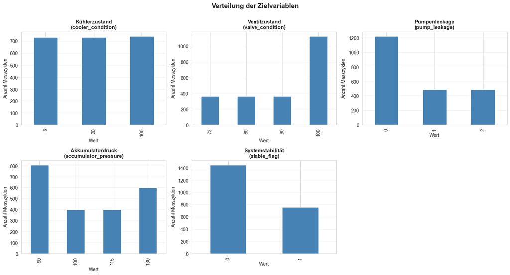

```python
# Visualisierung der Zielvariablen
fig, axes = plt.subplots(2, 3, figsize=(15, 8))
axes = axes.flatten()

# Bessere Namen für die Plots
target_labels = {
    'cooler_condition': 'Kühlerzustand',
    'valve_condition': 'Ventilzustand',
    'pump_leakage': 'Pumpenleckage',
    'accumulator_pressure': 'Akkumulatordruck',
    'stable_flag': 'Systemstabilität'
}

for idx, col in enumerate(targets.columns):
    targets[col].value_counts().sort_index().plot(
        kind='bar', ax=axes[idx], color='steelblue'
    )
    # Titel mit deutscher Bezeichnung UND technischem Namen
    axes[idx].set_title(f'{target_labels.get(col, col)}\n({col})',
                        fontsize=11, fontweight='bold')
    axes[idx].set_xlabel('Wert')
    axes[idx].set_ylabel('Anzahl Messzyklen')
    axes[idx].grid(axis='y', alpha=0.3)

# Letzte Subplot leer lassen
axes[-1].axis('off')

plt.suptitle('Verteilung der Zielvariablen', fontsize=14, fontweight='bold', y=1.00)
plt.tight_layout()
plt.show()
```

### Mathematischer Grund für r ≈ 1.0 zwischen Features

**Problem:** Viele Features zeigen Korrelation r ≥ 0.99 zu anderen Features.

**Erklärung am Beispiel: `max` vs. `range`**

Wenn Messwerte zwischen `x_min` und `x_max` liegen:

- `range = x_max - x_min`
- Bei hoher Variabilität im Sensor (großer `range`):
  - → `x_max` ist große Werte hat → **hohe Amplitude**
  - → `range` ist auch groß
  - → Beide korrelieren mit der **gleichen Variabilität** → r ≈ 1.0

**Mathematik:**

```
Korrelation ≈ 1.0 wenn beide Features
  → Linear abhängig sind
  → Gleiche Streuung (Varianz) erfassen
  → Gleiche Information tragen
```

**Consequence:** Deshalb ist Feature Selection sinnvoll — viele Features sind mathematisch redundant!

**Insight:** Top 10 per Target helfen hier: Wir wählen nur Features, die **zur Vorhersage der Zielgröße beitragen**, nicht einfach verschiedene Wege dieselbe Information zu messen.

```python
# Aggregierte Features laden (aus prep_corrected.py generiert)
# Falls noch nicht vorhanden, führe zuerst prep_corrected.py aus

if (OUT_DIR / 'features_complete.csv').exists():
    df = pd.read_csv(OUT_DIR / 'features_complete.csv')
    print(f"✓ Aggregierte Features erfolgreich geladen")
    print(f"\nShape: {df.shape}")
    print(f"Spalten: {df.shape[1]} (136 Features + 5 Zielvariablen)")
    print(f"Zeilen: {df.shape[0]} Messzyklen\n")

    # Feature-Gruppen nach Sensor
    sensor_names = [
        'ps1', 'ps2', 'ps3', 'ps4', 'ps5', 'ps6',
        'eps1', 'fs1', 'fs2', 'ts1', 'ts2', 'ts3', 'ts4',
        'vs1', 'ce', 'cp', 'se'
    ]

    print("=" * 70)
    print("SENSOREN IM DATASET")
    print("=" * 70)
    for sensor in sensor_names:
        sensor_cols = [col for col in df.columns if col.startswith(f'{sensor}_')]
        if sensor_cols:
            print(f"{sensor:5s} → {len(sensor_cols):2d} Features: {', '.join([c.split('_')[1] for c in sensor_cols])}")

    # Erste Zeilen anzeigen
    print("\n" + "=" * 70)
    print("ERSTE ZEILEN DES AGGREGIERTEN DATASETS")
    print("=" * 70)
    display(df.head())
else:
    print("❌ Datei nicht gefunden!")
    print("Führe zuerst 'python prep_corrected.py' aus, um die Features zu generieren.")
```

```
✓ Aggregierte Features erfolgreich geladen

Shape: (2205, 141)
Spalten: 141 (136 Features + 5 Zielvariablen)
Zeilen: 2205 Messzyklen

======================================================================
SENSOREN IM DATASET
======================================================================
ps1   →  8 Features: mean, std, min, max, median, q25, q75, range
ps2   →  8 Features: mean, std, min, max, median, q25, q75, range
ps3   →  8 Features: mean, std, min, max, median, q25, q75, range
ps4   →  8 Features: mean, std, min, max, median, q25, q75, range
ps5   →  8 Features: mean, std, min, max, median, q25, q75, range
ps6   →  8 Features: mean, std, min, max, median, q25, q75, range
eps1  →  8 Features: mean, std, min, max, median, q25, q75, range
fs1   →  8 Features: mean, std, min, max, median, q25, q75, range
fs2   →  8 Features: mean, std, min, max, median, q25, q75, range
ts1   →  8 Features: mean, std, min, max, median, q25, q75, range
ts2   →  8 Features: mean, std, min, max, median, q25, q75, range
ts3   →  8 Features: mean, std, min, max, median, q25, q75, range
ts4   →  8 Features: mean, std, min, max, median, q25, q75, range
vs1   →  8 Features: mean, std, min, max, median, q25, q75, range
ce    →  8 Features: mean, std, min, max, median, q25, q75, range
cp    →  8 Features: mean, std, min, max, median, q25, q75, range
se    →  8 Features: mean, std, min, max, median, q25, q75, range

======================================================================
ERSTE ZEILEN DES AGGREGIERTEN DATASETS
======================================================================
```

|  | ce_mean | ce_std | ce_min | ce_max | ce_median | ce_q25 | ce_q75 | ce_range | cp_mean | cp_std | ... | vs1_max | vs1_median | vs1_q25 | vs1_q75 | vs1_range | cooler_condition | valve_condition | pump_leakage | accumulator_pressure | stable_flag |
| --- | --- | --- | --- | --- | --- | --- | --- | --- | --- | --- | --- | --- | --- | --- | --- | --- | --- | --- | --- | --- | --- |
| 0 | 39.601350 | 6.370535 | 28.866 | 47.438 | 40.6755 | 33.61075 | 45.93825 | 18.572 | 1.862750 | 0.279385 | ... | 0.624 | 0.5770 | 0.55300 | 0.60300 | 0.092 | 3 | 100 | 0 | 130 | 1 |
| 1 | 25.786433 | 1.686129 | 23.320 | 29.208 | 25.3855 | 24.40025 | 27.24150 | 5.888 | 1.255550 | 0.074605 | ... | 0.626 | 0.5595 | 0.54700 | 0.57850 | 0.102 | 3 | 100 | 0 | 130 | 1 |
| 2 | 22.218233 | 0.638345 | 21.220 | 23.554 | 22.1040 | 21.64050 | 22.74900 | 2.334 | 1.113217 | 0.023263 | ... | 0.662 | 0.5620 | 0.54925 | 0.59525 | 0.133 | 3 | 100 | 0 | 130 | 1 |
| 3 | 20.459817 | 0.455755 | 19.673 | 21.565 | 20.4805 | 20.13825 | 20.71025 | 1.892 | 1.062150 | 0.024621 | ... | 0.645 | 0.5550 | 0.54775 | 0.59200 | 0.118 | 3 | 100 | 0 | 130 | 1 |
| 4 | 19.787017 | 0.290156 | 19.133 | 20.460 | 19.7985 | 19.63250 | 19.96675 | 1.327 | 1.070467 | 0.021477 | ... | 0.660 | 0.5760 | 0.54850 | 0.59275 | 0.136 | 3 | 100 | 0 | 130 | 1 |

5 rows × 141 columns

## 4. Missing Values

Laut Doku sollte der Datensatz keine fehlenden Werte enthalten.

Dennoch kurze Absicherung:

```python
if 'df' in locals():
    # Anzahl fehlender Werte pro Spalte
    missing_counts = df.isnull().sum()
    missing_total = missing_counts.sum()

    print("=" * 70)
    print("MISSING VALUES ANALYSE")
    print("=" * 70)
    print(f"Gesamtanzahl fehlender Werte: {missing_total}")
    print(f"Prozentsatz: {(missing_total / (df.shape[0] * df.shape[1]) * 100):.2f}%")

    if missing_total > 0:
        print("\nSpalten mit fehlenden Werten:")
        print(missing_counts[missing_counts > 0].sort_values(ascending=False))
    else:
        print("\n✓ KEINE FEHLENDEN WERTE GEFUNDEN!")
        print("Der Datensatz ist vollständig.")

    # Visualisierung (falls fehlende Werte existieren)
    if missing_total > 0:
        plt.figure(figsize=(12, 6))
        missing_counts[missing_counts > 0].sort_values(ascending=False).plot(kind='bar')
        plt.title('Missing Values pro Spalte', fontsize=14, fontweight='bold')
        plt.xlabel('Spalte')
        plt.ylabel('Anzahl fehlender Werte')
        plt.xticks(rotation=45, ha='right')
        plt.tight_layout()
        plt.show()
else:
    print("❌ Dataset nicht geladen. Führe zuerst die vorherigen Zellen aus.")
```

```
======================================================================
MISSING VALUES ANALYSE
======================================================================
Gesamtanzahl fehlender Werte: 0
Prozentsatz: 0.00%

✓ KEINE FEHLENDEN WERTE GEFUNDEN!
Der Datensatz ist vollständig.
```

## 5. Plausibilitätsprüfung der Attribute

Wir prüfen die statistischen Kennzahlen jedes Features, um Ausreißer oder Probleme zu identifizieren:

- **Min/Max:** Wertebereich plausibel?
- **Mean vs. Median:** Hinweise auf Schiefe (Skewness)?
- **Stbw:** Variabilität der Daten

```python
if 'df' in locals():
    # Nur numerische Features (ohne Zielvariablen)
    feature_cols = [col for col in df.columns if '_' in col and col not in targets.columns]
    features_only = df[feature_cols]

    # Deskriptive Statistiken
    stats = features_only.describe().T

    print("=" * 70)
    print("DESKRIPTIVE STATISTIKEN DER FEATURES")
    print("=" * 70)
    print(f"Anzahl Features: {len(feature_cols)}\n")

    # Erste 20 Features anzeigen
    display(stats.head(20))

    print("\n" + "=" * 70)
    print("PLAUSIBILITÄTSPRÜFUNG")
    print("=" * 70)

    # Features mit negativen Werten (falls nicht erwartet)
    negative_mins = stats[stats['min'] < 0]
    if len(negative_mins) > 0:
        print(f"\n⚠ Features mit negativen Werten: {len(negative_mins)}")
        print(negative_mins[['min', 'max', 'mean']].head(10))
    else:
        print("\n✓ Keine negativen Werte gefunden")

    # Features mit sehr hoher Standardabweichung (möglicherweise Ausreißer)
    high_std = stats[stats['std'] > stats['mean']].sort_values('std', ascending=False)
    if len(high_std) > 0:
        print(f"\n⚠ Features mit STD > MEAN (hohe Variabilität): {len(high_std)}")
        print(high_std[['mean', 'std', 'min', 'max']].head(10))

    # Features mit konstanten/sehr geringen Werten
    low_std = stats[stats['std'] < 0.01].sort_values('std')
    if len(low_std) > 0:
        print(f"\n⚠ Features mit sehr geringer Variabilität (STD < 0.01): {len(low_std)}")
        print(low_std[['mean', 'std', 'min', 'max']].head(10))
    else:
        print("\n✓ Alle Features haben ausreichende Variabilität")

else:
    print("❌ Dataset nicht geladen.")
```

```
======================================================================
DESKRIPTIVE STATISTIKEN DER FEATURES
======================================================================
Anzahl Features: 136
```

|  | count | mean | std | min | 25% | 50% | 75% | max |
| --- | --- | --- | --- | --- | --- | --- | --- | --- |
| ce_mean | 2205.0 | 31.299077 | 11.575330 | 17.555983 | 20.084650 | 27.392533 | 46.677383 | 47.903667 |
| ce_std | 2205.0 | 0.287325 | 0.199760 | 0.063164 | 0.217363 | 0.264125 | 0.329684 | 6.370535 |
| ce_min | 2205.0 | 30.785665 | 11.583481 | 17.042000 | 19.513000 | 26.862000 | 46.168000 | 47.626000 |
| ce_max | 2205.0 | 31.880312 | 11.602740 | 18.142000 | 20.694000 | 27.983000 | 47.272000 | 48.777000 |
| ce_median | 2205.0 | 31.287446 | 11.570829 | 17.501000 | 20.083000 | 27.363500 | 46.648500 | 47.945000 |
| ce_q25 | 2205.0 | 31.078011 | 11.574876 | 17.362000 | 19.875750 | 27.151250 | 46.474750 | 47.772750 |
| ce_q75 | 2205.0 | 31.506510 | 11.574789 | 17.746000 | 20.345000 | 27.592000 | 46.856250 | 48.129000 |
| ce_range | 2205.0 | 1.094648 | 0.585637 | 0.375000 | 0.871000 | 1.048000 | 1.241000 | 18.572000 |
| cp_mean | 2205.0 | 1.808399 | 0.278263 | 1.062150 | 1.550100 | 1.739683 | 2.148483 | 2.840100 |
| cp_std | 2205.0 | 0.022692 | 0.011138 | 0.006914 | 0.018377 | 0.021472 | 0.025096 | 0.343522 |
| cp_min | 2205.0 | 1.769092 | 0.282245 | 1.016000 | 1.502000 | 1.701000 | 2.115000 | 2.768000 |
| cp_max | 2205.0 | 1.855768 | 0.278504 | 1.105000 | 1.604000 | 1.786000 | 2.190000 | 2.909000 |
| cp_median | 2205.0 | 1.806442 | 0.277476 | 1.066000 | 1.550000 | 1.737000 | 2.145000 | 2.843000 |
| cp_q25 | 2205.0 | 1.791137 | 0.279099 | 1.045500 | 1.532750 | 1.719750 | 2.133750 | 2.814750 |
| cp_q75 | 2205.0 | 1.824328 | 0.277262 | 1.077000 | 1.570000 | 1.756750 | 2.159250 | 2.862000 |
| cp_range | 2205.0 | 0.086676 | 0.033147 | 0.034000 | 0.073000 | 0.083000 | 0.095000 | 0.952000 |
| eps1_mean | 2205.0 | 2495.509203 | 73.836682 | 2361.747267 | 2442.933467 | 2480.926633 | 2548.211467 | 2740.641000 |
| eps1_std | 2205.0 | 203.489501 | 27.766181 | 185.105121 | 188.986584 | 196.153664 | 198.926555 | 294.046838 |
| eps1_min | 2205.0 | 2267.717914 | 65.422202 | 2097.800000 | 2202.800000 | 2260.000000 | 2341.600000 | 2384.000000 |
| eps1_max | 2205.0 | 2900.794921 | 49.647523 | 2813.400000 | 2853.000000 | 2897.400000 | 2951.400000 | 2995.200000 |

```
======================================================================
PLAUSIBILITÄTSPRÜFUNG
======================================================================

✓ Keine negativen Werte gefunden

⚠ Features mit STD > MEAN (hohe Variabilität): 10
                    mean       std       min        max
ps4_max     3.172446e+00  4.349040  0.000000  10.266000
ps4_q75     2.636674e+00  4.302525  0.000000  10.226000
ps4_median  2.572349e+00  4.295579  0.000000  10.207000
ps4_q25     2.536717e+00  4.290085  0.000000  10.190000
ps4_mean    2.600266e+00  4.279355  0.000000  10.207068
ps4_min     2.475427e+00  4.257247  0.000000  10.133000
ps4_range   6.970190e-01  1.733458  0.000000  10.238000
ps4_std     1.107360e-01  0.390756  0.000000   4.529653
ts4_std     4.352992e-02  0.052920  0.008342   1.442105
fs1_min     4.535147e-07  0.000021  0.000000   0.001000

⚠ Features mit sehr geringer Variabilität (STD < 0.01): 7
                 mean       std       min       max
ps3_min  0.000000e+00  0.000000  0.000000  0.000000
ps2_min  0.000000e+00  0.000000  0.000000  0.000000
se_min   0.000000e+00  0.000000  0.000000  0.000000
fs1_min  4.535147e-07  0.000021  0.000000  0.001000
ps5_std  2.225296e-02  0.002095  0.020142  0.088154
ps6_std  2.245055e-02  0.002104  0.020164  0.085366
fs2_std  1.716132e-02  0.004020  0.012419  0.091772
```

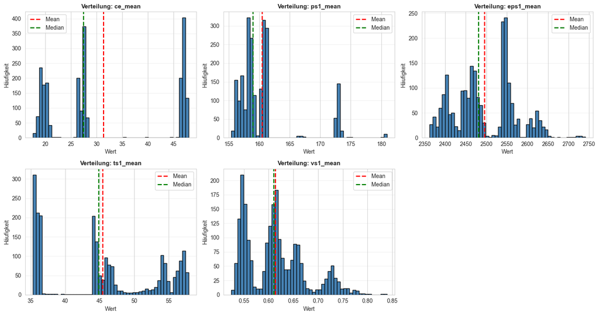

```python
if 'df' in locals():
    # Verteilung einiger wichtiger Features visualisieren
    important_features = ['ce_mean', 'ps1_mean', 'eps1_mean', 'ts1_mean', 'vs1_mean']
    available_features = [f for f in important_features if f in df.columns]

    if len(available_features) > 0:
        fig, axes = plt.subplots(2, 3, figsize=(15, 8))
        axes = axes.flatten()

        for idx, feature in enumerate(available_features):
            df[feature].hist(bins=50, ax=axes[idx], color='steelblue', edgecolor='black')
            axes[idx].set_title(f'Verteilung: {feature}', fontsize=11, fontweight='bold')
            axes[idx].set_xlabel('Wert')
            axes[idx].set_ylabel('Häufigkeit')
            axes[idx].axvline(df[feature].mean(), color='red', linestyle='--', linewidth=2, label='Mean')
            axes[idx].axvline(df[feature].median(), color='green', linestyle='--', linewidth=2, label='Median')
            axes[idx].legend()
            axes[idx].grid(axis='y', alpha=0.3)

        # Nicht verwendete Subplots ausblenden
        for idx in range(len(available_features), len(axes)):
            axes[idx].axis('off')

        plt.tight_layout()
        plt.show()
else:
    print("❌ Dataset nicht geladen.")
```

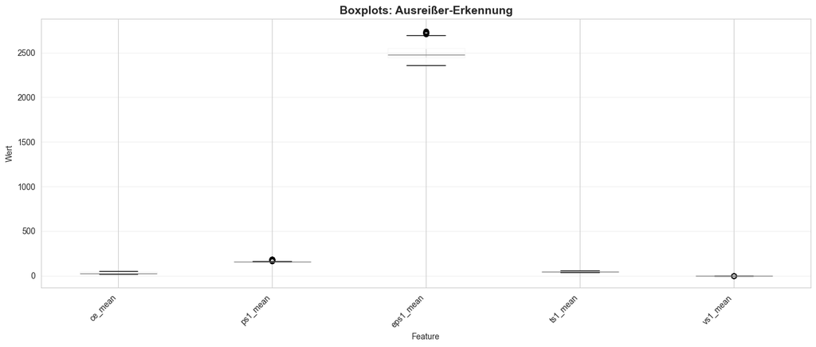

```python
if 'df' in locals():
    # Boxplots für Ausreißer-Erkennung
    sample_features = ['ce_mean', 'ps1_mean', 'eps1_mean', 'ts1_mean', 'vs1_mean']
    available_features = [f for f in sample_features if f in df.columns]

    if len(available_features) > 0:
        plt.figure(figsize=(14, 6))
        df[available_features].boxplot(figsize=(14, 6))
        plt.title('Boxplots: Ausreißer-Erkennung', fontsize=14, fontweight='bold')
        plt.ylabel('Wert')
        plt.xlabel('Feature')
        plt.xticks(rotation=45, ha='right')
        plt.grid(axis='y', alpha=0.3)
        plt.tight_layout()
        plt.show()
else:
    print("❌ Dataset nicht geladen.")
```

## 6. Korrelationsanalyse

Grundlegende Korrelationsanalyse um:

- **Redundante Features** zu identifizieren (hohe Korrelation)
- **Wichtige Zusammenhänge** zu verstehen
- **Features für theoretische Modellierung** auszuwählen

```python
if 'df' in locals():
    # Korrelationsmatrix berechnen (nur Features, keine Targets)
    feature_cols = [col for col in df.columns if '_' in col and col not in targets.columns]
    corr_matrix = df[feature_cols].corr()

    print("=" * 70)
    print("KORRELATIONSMATRIX")
    print("=" * 70)
    print(f"Shape: {corr_matrix.shape}")
    print(f"Anzahl Korrelations-Paare: {(corr_matrix.shape[0] * (corr_matrix.shape[0] - 1)) // 2}")

    # Hohe Korrelationen finden (> 0.9)
    high_corr = []
    for i in range(len(corr_matrix.columns)):
        for j in range(i+1, len(corr_matrix.columns)):
            if abs(corr_matrix.iloc[i, j]) > 0.9:
                high_corr.append({
                    'Feature 1': corr_matrix.columns[i],
                    'Feature 2': corr_matrix.columns[j],
                    'Correlation': corr_matrix.iloc[i, j]
                })

    if len(high_corr) > 0:
        print(f"\n⚠ Hohe Korrelationen gefunden (|r| > 0.9): {len(high_corr)}")
        high_corr_df = pd.DataFrame(high_corr).sort_values('Correlation', key=abs, ascending=False)
        display(high_corr_df.head(20))
    else:
        print("\n✓ Keine extrem hohen Korrelationen gefunden (|r| > 0.9)")
else:
    print("❌ Dataset nicht geladen.")
```

```
======================================================================
KORRELATIONSMATRIX
======================================================================
Shape: (136, 136)
Anzahl Korrelations-Paare: 9180

⚠ Hohe Korrelationen gefunden (|r| > 0.9): 1992

⚠ Hohe Korrelationen gefunden (|r| > 0.9): 1992
```

|  | Feature 1 | Feature 2 | Correlation |
| --- | --- | --- | --- |
| 1673 | se_max | se_range | 1.000000 |
| 1240 | ps2_max | ps2_range | 1.000000 |
| 1287 | ps3_max | ps3_range | 1.000000 |
| 793 | fs1_max | fs1_range | 1.000000 |
| 1512 | ps6_mean | ps6_median | 0.999999 |
| 1316 | ps5_mean | ps5_median | 0.999999 |
| 1959 | ts4_mean | ts4_median | 0.999997 |
| 824 | fs2_mean | fs2_median | 0.999997 |
| 1901 | ts3_mean | ts3_median | 0.999996 |
| 1595 | ps6_median | ps6_q75 | 0.999996 |
| 1677 | ts1_mean | ts1_median | 0.999996 |
| 1514 | ps6_mean | ps6_q75 | 0.999995 |
| 1418 | ps5_median | ps5_q75 | 0.999995 |
| 1318 | ps5_mean | ps5_q75 | 0.999995 |
| 1513 | ps6_mean | ps6_q25 | 0.999995 |
| 1317 | ps5_mean | ps5_q25 | 0.999995 |
| 1807 | ts2_mean | ts2_median | 0.999994 |
| 1902 | ts3_mean | ts3_q25 | 0.999994 |
| 1417 | ps5_median | ps5_q25 | 0.999993 |
| 1594 | ps6_median | ps6_q25 | 0.999993 |

```python
if 'df' not in locals() or 'targets' not in locals():
    print("❌ FEHLER: df oder targets nicht geladen!")
    print("Bitte führe die vorherigen Zellen aus (Abschnitte 1-3).")
else:
    # Feature-Spalten extrahieren (alle mit '_' außer Zielvariablen)
    feature_cols = [col for col in df.columns if '_' in col and col not in targets.columns]
    print(f"✓ Setup für Korrelationsanalyse erfolgreich")
    print(f"  - DataFrame shape: {df.shape}")
    print(f"  - Feature-Spalten: {len(feature_cols)}")
    print(f"  - Ziel-Spalten: {len(targets.columns)}")
    print(f"  - Ready for Section 6!")
```

```
✓ Setup für Korrelationsanalyse erfolgreich
  - DataFrame shape: (2205, 141)
  - Feature-Spalten: 136
  - Ziel-Spalten: 5
  - Ready for Section 6!
```

### 💡 Interpretation der hohen Korrelationen

Die obige Tabelle zeigt **perfekte Korrelationen (r ≈ 1.0)** zwischen bestimmten Feature-Paaren. Das ist **mathematisch erwartbar** und kein Fehler:

**Perfekte Korrelationen (r = 1.0):**

- `max` ↔ `range`: Da `range = max - min` ist, und `min` konstant ist, sind diese Features perfekt korreliert
- Beispiel: `ps2_max` und `ps2_range` haben r = 1.0

**Sehr hohe Korrelationen (r > 0.999):**

- `mean` ↔ `median` ↔ `q25` ↔ `q75`: Bei symmetrischen Verteilungen (ohne Ausreißer) sind diese Lagemaße nahezu identisch
- Beispiel: `ps6_mean`, `ps6_median`, `ps6_q25`, `ps6_q75` korrelieren alle mit r > 0.999

**Konsequenzen für die Modellierung:**

- ✅ **Feature Selection notwendig:** Redundante Features können entfernt werden (z.B. `range` wenn `max` vorhanden)
- ✅ **Dimensionality Reduction:** PCA oder Lasso Regularization könnten helfen
- ⚠ **Multikollinearität:** Bei linearen Modellen (z.B. Lineare Regression) problematisch
- ✓ **Tree-based Modelle** (Random Forest, XGBoost) sind robust gegenüber hohen Korrelationen

**Fazit:** Die hohen Korrelationen sind **plausibel** und zeigen, dass die Sensoren in stabilen Bereichen messen. Für ML-Modelle sollten wir redundante Features entfernen.

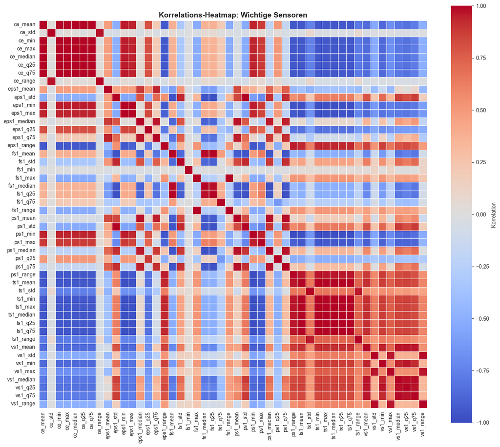

```python
if 'df' in locals():
    # Heatmap der Korrelationsmatrix (Ausschnitt für bessere Lesbarkeit)
    # Wähle eine Teilmenge von Features für die Visualisierung
    important_sensors = ['ce', 'ps1', 'eps1', 'ts1', 'vs1', 'fs1']
    subset_cols = [col for col in feature_cols if any(col.startswith(f'{s}_') for s in important_sensors)]

    if len(subset_cols) > 0:
        corr_subset = df[subset_cols].corr()

        plt.figure(figsize=(14, 12))
        sns.heatmap(
            corr_subset,
            annot=False,  # Keine Zahlen in Zellen (zu viele Features)
            cmap='coolwarm',
            center=0,
            vmin=-1,
            vmax=1,
            square=True,
            linewidths=0.5,
            cbar_kws={'label': 'Korrelation'}
        )
        plt.title('Korrelations-Heatmap: Wichtige Sensoren', fontsize=14, fontweight='bold')
        plt.tight_layout()
        plt.show()
else:
    print("❌ Dataset nicht geladen.")
```

```python
if 'df' in locals() and 'targets' in locals():
    # Feature-Spalten sicherstellen
    feature_cols = [col for col in df.columns if '_' in col and col not in targets.columns]

    print("=" * 70)
    print("KORRELATION: FEATURES vs. ZIELVARIABLEN")
    print("=" * 70)

    for target_col in targets.columns:
        if target_col in df.columns:
            # Top 10 Features mit höchster Korrelation zur Zielvariable
            target_corr = df[feature_cols].corrwith(df[target_col]).abs().sort_values(ascending=False)

            print(f"\n{target_col.upper()}:")
            print("-" * 70)
            print(target_corr.head(10))
        else:
            print(f"\n⚠ {target_col} nicht in DataFrame gefunden")
else:
    print("❌ Dataset oder Zielvariablen nicht geladen.")
```

```
======================================================================
KORRELATION: FEATURES vs. ZIELVARIABLEN
======================================================================

COOLER_CONDITION:
----------------------------------------------------------------------
ce_q25       0.992062
ce_min       0.992038
ce_mean      0.991943
ce_median    0.991902
ce_q75       0.991507
ce_max       0.991238
cp_min       0.957230
cp_q25       0.957230
cp_mean      0.956220
cp_median    0.955641
dtype: float64

VALVE_CONDITION:
----------------------------------------------------------------------
se_mean      0.231354
ps2_std      0.207383
fs1_mean     0.190141
fs1_max      0.181891
fs1_range    0.181890
se_q75       0.177244
eps1_mean    0.174618
se_median    0.172288
se_q25       0.171737
fs1_q25      0.167301
dtype: float64

PUMP_LEAKAGE:
----------------------------------------------------------------------
se_mean        0.469243
se_q75         0.449402
eps1_mean      0.426320
eps1_q75       0.423309
fs1_mean       0.421702
se_q25         0.406394
```

[output cut: 18 more lines]

```
dtype: float64

STABLE_FLAG:
----------------------------------------------------------------------
se_mean      0.324695
fs1_max      0.290922
fs1_range    0.290921
fs1_mean     0.288568
se_q25       0.274363
se_q75       0.273904
se_median    0.273156
eps1_q75     0.270526
ps2_std      0.267960
eps1_mean    0.267649
dtype: float64
```

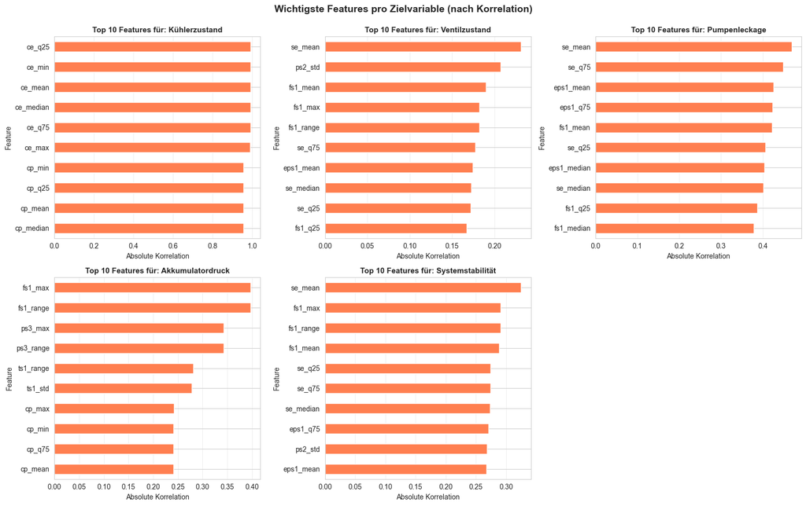

```
✓ 5 Plots erfolgreich generiert
```

```python
if 'df' in locals() and 'targets' in locals():
    # Feature-Spalten sicherstellen
    feature_cols = [col for col in df.columns if '_' in col and col not in targets.columns]

    # Visualisierung: Top Features pro Zielvariable
    fig, axes = plt.subplots(2, 3, figsize=(16, 10))
    axes = axes.flatten()

    target_labels = {
        'cooler_condition': 'Kühlerzustand',
        'valve_condition': 'Ventilzustand',
        'pump_leakage': 'Pumpenleckage',
        'accumulator_pressure': 'Akkumulatordruck',
        'stable_flag': 'Systemstabilität'
    }

    plot_count = 0
    for idx, target_col in enumerate(targets.columns):
        if target_col in df.columns:
            # Top 10 Features mit höchster Korrelation
            target_corr = df[feature_cols].corrwith(df[target_col]).abs().sort_values(ascending=False).head(10)

            if len(target_corr) > 0:
                target_corr.plot(kind='barh', ax=axes[idx], color='coral')
                axes[idx].set_title(f'Top 10 Features für: {target_labels.get(target_col, target_col)}',
                                    fontsize=11, fontweight='bold')
                axes[idx].set_xlabel('Absolute Korrelation')
                axes[idx].set_ylabel('Feature')
                axes[idx].grid(axis='x', alpha=0.3)
                axes[idx].invert_yaxis()  # Höchste Korrelation oben
                plot_count += 1
            else:
                axes[idx].text(0.5, 0.5, f'Keine Daten für\n{target_col}',
                              ha='center', va='center', fontsize=12)
                axes[idx].axis('off')

    # Letzte Subplot leer lassen
    axes[-1].axis('off')

    plt.suptitle('Wichtigste Features pro Zielvariable (nach Korrelation)',
                 fontsize=14, fontweight='bold', y=0.995)
    plt.tight_layout()
    plt.show()
    print(f"✓ {plot_count} Plots erfolgreich generiert")
else:
    print("❌ Dataset oder Zielvariablen nicht geladen.")
```

## Zusammenfassung

### Analyseschritte

1. **Beschreibung** - 2.205 Messzyklen mit 5 Zielvariablen
2. **Aggregation** - Von 43.680 Spalten zu 136 Features
3. **Missings** - Keine fehlenden Werte im Dataset
4. **Plausibilität** - Min/Max, Mean/Median, Standardabweichung
5. **Korrelationen** - Zusammenhänge zwischen Features und Zielvariablen